# Homework 6

Ziyang (Bob) Ding

05 March, 2020

# Problem 1

**In the exponential family, EM computations are somewhat simplified. Show that if the complete data density $f$ is of the form**
$$\begin{aligned}
f(y, z | \theta)=h(y, z) \exp \{\eta(\theta) T(y, z)-C(\theta)\}
\end{aligned}$$

**then we can write**

$$\begin{aligned}
Q\left(\theta | \theta^{(t)}, y\right)=E_{\theta^{(t)}}[\log (h(y, Z))]+\sum \eta_{i}(\theta) E_{\theta^{(t)}}\left[T_{i} | y\right]-C(\theta)
\end{aligned}$$

**so that calculating the complete data MLE only involves the simpler expectation $E_{\theta^{(t)}}\left[T_{i} | y\right],$ the expected sufficient statistics.}**

**Proof**

$$\begin{aligned}
Q(\theta | \theta^t, y) &= \bE_{z|y,\theta^t}[\log f(y,z|\theta)]\\
&= \bE_{z|y,\theta^t}[\log h(y, z) \exp \{\eta(\theta) T(y, z)-C(\theta)\}]\\
&= \bE_{z|y,\theta^t}[\log h(y, z) + \eta(\theta) T(y, z)-C(\theta)]\\
&= \bE_{\theta^t}[\log h(y, z)] + \sum \eta_i(\theta) \bE_{\theta^t}[T_i|y]-C(\theta)\\
\end{aligned}$$

# Problem 2

**For the situation of Example $5.21,$ data $\left(x_{1}, x_{2}, x_{3}, x_{4}\right)=(125,18,20,34)$ are collected.**

*(a) **Use the EM algorithm to find the MLE of $\theta$.**

*(b) **(b) Use the Monte Carlo EM algorithm to find the MLE of $\theta .$ Compare your results to those of part (a).**

&nbsp

**Proof**

$$\begin{aligned}
\theta^{(t+1)}=\frac{\frac{\theta^{(t)} x_{1}}{2+\theta_{0}}+x_{4}}{\frac{\theta^{(t)} x_{1}}{2+\theta_{0}}+x_{2}+x_{3}+x_{4}}
\end{aligned}$$

```r
x1 = 125
x2 = 18
x3 = 20
x4 = 34
EM = function(n){
theta = rep(0, n)
for(i in 2:n){
tmp = theta[i-1]*x1/(2+theta[i-1])
theta[i] = (tmp+x4)/(tmp+x2+x3+x4)
}
return (theta[n])
}
t = EM(100)
print(t)
```

```
## [1] 0.6268215
```

$$\begin{aligned}
\theta^{(t+1)}=\frac{\frac{1}{m} \sum_{i=1}^{m} z_{i}+x_{4}}{\frac{1}{m} \sum_{i=1}^{m} z_{i}+x_{2}+x_{3}+x_{4}}
\end{aligned}$$

```r
MCEM = function(n,m){
theta = rep(0, n)
for(i in 2:n){
zm = sum(rbinom(m, x1, theta[i-1]/(2+theta[i-1])))/m
theta[i] = (zm+x4)/(zm+x2+x3+x4)
}
return(theta[n])
}
MCEM(100, 100)
```

```
## [1] 0.6249136
```

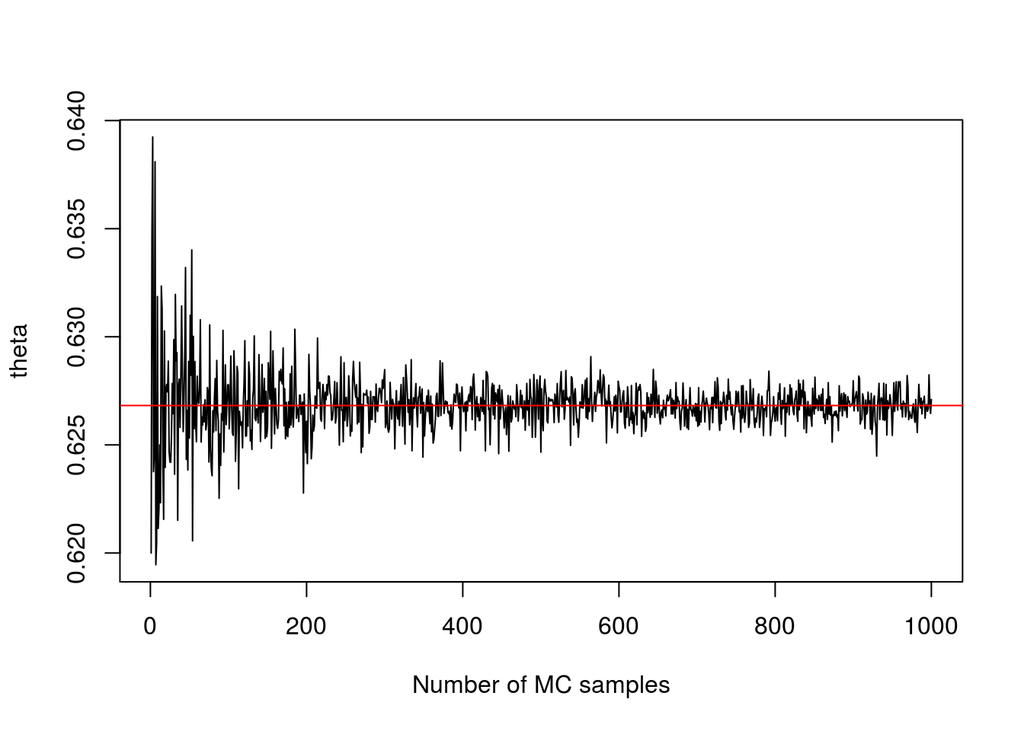

```r
th = rep(0,1000)
for(m in 1:1000){
th[m] = MCEM(100, m)
}
plot(1:1000, th, xlab = 'Number of MC samples', ylab = 'theta', type = 'l')
abline(t,0, col = 'red')
```

# Problem 3

**The EM algorithm can also be implemented in a Bayesian hierarchical model to find a posterior mode. Suppose that we have the hierarchical model $X|\theta \sim f(x | \theta)$**

$$\begin{aligned}
\begin{array}{l}
\theta|\lambda \sim \pi(\theta | \lambda) \\
\lambda \sim \gamma(\lambda)
\end{array}
\end{aligned}$$

**where interest would be in estimating quantities from $\pi(\theta | x) .$ since**

$$\begin{aligned}
\pi(\theta | x)=\int \pi(\theta, \lambda | x) d \lambda
\end{aligned}$$

**where $\pi(\theta, \lambda | x)=\pi(\theta | \lambda, x) \pi(\lambda | x),$ the EM algorithm is a candidate method for finding the mode of $\pi(\theta | x)$, where $\lambda$ would be used as the augmented data.**

- 1. **Define $k(\lambda | \theta, x)=\pi(\theta, \lambda | x) / \pi(\theta | x)$ and show that**

$$\begin{aligned}
\log \pi(\theta | x)=\int \log \pi(\theta, \lambda | x) k\left(\lambda | \theta^{*}, x\right) d \lambda-\int \log k(\lambda | \theta, x) k\left(\lambda | \theta^{*}, x\right) d \lambda
\end{aligned}$$

- 2. **If the sequence $\left(\hat{\theta}_{(j)}\right)$ satisfies**

$$\begin{aligned}
\max _{\theta} \int \log \pi(\theta, \lambda | x) k\left(\lambda | \theta_{(j)}, x\right) d \lambda=\int \log \pi\left(\theta_{(j+1)}, \lambda | x\right) k\left(\lambda | \theta_{(j)}, x\right) d \lambda
\end{aligned}$$

**show that $\log \pi\left(\theta_{(j+1)} | x\right) \geq \log \pi\left(\theta_{(j)} | x\right) .$ Under what conditions will the sequence $\left(\hat{\theta}_{(j)}\right)$ converge to the mode of $\pi(\theta | x) ?$**

- 3. **For the hierarchy**

$$\begin{aligned}
\begin{array}{l}
X | \theta \sim \mathcal{N}(\theta, 1) \\
\theta | \lambda \sim \mathcal{N}(\lambda, 1)
\end{array}
\end{aligned}$$

**with $\pi(\lambda)=1,$ show how to use the EM algorithm to calculate the posterior mode of $\pi(\theta | x)$**

**Proof**

$$\begin{aligned}
\log \pi(\theta | x) &= \log \pi(\theta, \lambda | x)-\log k(\lambda | \theta, x) \\
\log \pi(\theta | x) k\left(\lambda | \theta^{*}, x\right) &=\log \pi(\theta, \lambda | x) k\left(\lambda | \theta^{*}, x\right)-\log k(\lambda | \theta, x) k\left(\lambda | \theta^{*}, x\right) \\
\int \log \pi(\theta | x) k\left(\lambda | \theta^{*}, x\right) d \lambda &=\log \pi(\theta, \lambda | x) k\left(\lambda | \theta^{*}, x\right) d \lambda-\log k(\lambda | \theta, x) k\left(\lambda | \theta^{*}, x\right) d \lambda \\
\log \pi(\theta, \lambda | x) &=\log \pi(\theta, \lambda | x) k\left(\lambda | \theta^{*}, x\right) d \lambda-\log k(\lambda | \theta, x) k\left(\lambda | \theta^{*}, x\right) d \lambda
\end{aligned}$$

$$\begin{array}{l}
\quad \int \log k(\lambda | \theta, x) k\left(\lambda | \theta_{(j)}, x\right) d \lambda-\int \log k\left(\lambda | \theta_{(j)}, x\right) k\left(\lambda | \theta_{(j)}, x\right) d \lambda \\
=\int \log \frac{k(\lambda | \theta, x)}{k\left(\lambda | \theta_{(j)}, x\right)} k\left(\lambda | \theta_{(j)}, x\right) d \lambda \\
\leq \log \int \frac{k(\lambda | \theta, x)}{k\left(\lambda | \theta_{(j)}, x\right)} k\left(\lambda | \theta_{(j)}, x\right) d \lambda\\
=0
\end{array}$$

Therefore, we know that EM always converge to a zero-gradient point given that $\log \pi(\theta | x)$ is concave (local maximum, local mimimum, saddle point).

$$\begin{aligned}
k(\lambda | \theta, x) &=\pi(\lambda | \theta, x) \\
&=\pi(\lambda | \theta) \\
& \propto \pi(\theta | \lambda) \\
& \propto e^{-\frac{(\lambda-\theta)^{2}}{2}} \\
& \sim N(\theta, 1) \\
\pi(\theta, \lambda | x) & \propto \pi(\theta, \lambda) \pi(x | \theta, \lambda) \\
& \propto e^{-\frac{(\lambda-\theta)^{2}}{2}} e^{-\frac{(x-\theta)^{2}}{2}} \\
Q\left(\theta | \theta_{(j)}\right)&=C+E_{\lambda | \theta_{(j)}}\left(-\frac{(\lambda-\theta)^{2}}{2}-\frac{(x-\theta)^{2}}{2}\right) & \\
&=C^{\prime}-\frac{(\theta-x)^{2}}{2}-\frac{\left(\theta-\theta_{j}\right)^{2}}{2} & \\
\theta_{j+1} &= \left(x+\theta_{j}\right) / 2 &
\end{aligned}$$

# Problem 4

**Let $M$ be a random matrix having standard Wishart distribution with $\nu$ d.o.f., and let $\Sigma=L L^{\prime}$ be symmetric positive definite. Show that $\tilde{M}=L M L^{\prime}$ has distribution $W_{p}(\Sigma, \nu)$**

**Proof**

$$\begin{aligned}
f(M)&\sim \text{IW}(I, \nu)\\
f(LML^T) &\sim \text{IW}(LIL^T,\nu ) = \text{IW}(\Sigma, \nu)
\end{aligned}$$